# Zhaoxin Ban HW1

1. Using the January 1987 data set in Table A.1, define event “A” as Ithaca Tmax > 32_F, and event “B” as Canandaigua Tmax > 32_F.
1. Explain the meanings of Pr(A), Pr(B), Pr(A, B), Pr(A B), Pr(A | B), and Pr(B | A).
2. Estimate, using relative frequencies in the data, Pr(A), Pr(B), and Pr(A, B).
3. Using the results from part (b), calculate Pr(A | B).
4. Are events “A” and “B” independent? How do you know?

Answer: Pr(A): probability of Ithaca Tmax > 32F; Pr(B): probability of Canandaigua Tmax>32F, Pr(A,B): probability of both Ithaca and Canandaigua have Tmax>32F; Pr(A B): probability of either Ithaca or Canandaigua’s Tmax > 32F; Pr(A|B): probability of Ithaca Tmax>32F knowing Canandaigua Tmax>32F; Pr(B|A): probability of Canandaigua Tmax>32F knowing Ithaca Tmax>32F. Pr(A)=(days of Tmax>32F in Ithaca)/(total days)=9/31~=0.29 Pr(B)=(days of Tmax>32F in Canandaigua)/(total days)=15/31~=0.48 Pr(A,B)=(days of both Ithaca and Canandaigua have Tmax>32F)/(total days)=9/31<sub>=0.29 Pr(A|B)=Pr(A,B)/Pr(B)=0.29/0.48</sub>=0.604 Pr(A)!=Pr(A|B), so events A and B are not independent, otherwise they should be equal.

2. The effect of cloud seeding on suppression of damaging hail is being studied in your area by randomly seeding or not seeding equal numbers of candidate storms. Suppose the probability of damaging hail from a seeded storm is 0.10, and the probability of damaging hail from an unseeded storm is 0.40. If one of the candidate storms has just produced damaging hail, what is the probability that it was seeded? Let S=seeded, D=damaging, US=unseeded, UD=undamaging. P(S|D)=P(D,S)/P(D)=P(D|S)*P(S)/(P(D|S)*P(S)+P(D|US)*P(US))=0.10.5/(0.1*0.5+0.4*0.5)=0.05/0.25=0.2 The probability that the storm was seeded is 0.2.

3.Perform an exploratory data analysis of the Tx and Tn time series, as well as their difference (the diurnal temperature range). Write a summary paragraph describing what you’ve found both statistically and scientifically. There is not a “right” way to do this data exploration, but you should at least create/examine: (a) histograms and kernel density estimates of the data as a function of month or season. Bonus question: try using a bin size of 0.5 C. You may notice strange behavior in your histograms. Any idea why? (b) summary statistics for winter Tx including the mean, median, standard deviation, mean absolute deviation, representative quantiles, skewness, and kurtosis. Calculate each of these quantities without using the built in functions in your language of choice, and print out the results. You can drop any missing values before doing the calculations.

1. first read in data

```r
setwd("C:/Users/zban/Downloads/2019 winter quarter/Modern Environmental Statistics/")
a <- read.table("Table A.1.txt",header=TRUE)
PA=length(which(a[,3]>32))/length(a[,3])
PB=length(which(a[,6]>32))/length(a[,6])
setwd("C:/Users/zban/Downloads/2019 winter quarter/Modern Environmental Statistics")
Tmax=read.table("USW00023174_TMAX_clean.csv",sep=",",header=T)
Tmin=read.table("USW00023174_TMIN_clean.csv",sep=",",header=T)
Trange=Tmax[,5]-Tmin[,5]
Trange=cbind(Tmax[,1:4],Trange)
Trange=Trange[which(abs(Trange[,5])<100),]
Trange=Trange[which(Trange[,5]!=0),]
Tmax=Tmax[which(Tmax[,5]!=-999.9),]
Tmin=Tmin[which(Tmin[,5]!=-999.9),]
month=c("Jan","Feb","Mar","Apr","May","Jun","Jul","Aug","Sep","Oct","Nov","Dec")
```

Define plot functions for monthly histogram and kernel density

```r
plotTx <- function(Tmax,m,month){
  X=Tmax[which(Tmax[,2]==m),5]
  hist(X,plot=TRUE,nclass=(max(X)-min(X))/0.5,col="red",main=paste0("Histogram of ",month[m]," Tmax"),xlab=paste0(month[m]," Tmax"),ylab="density",freq=FALSE)
  dens <- density(X,adjust=1,kernel=c("gaussian"))
  lines(dens,lwd=3)
}
plotTn <- function(Tmin,m,month){
  N=Tmin[which(Tmin[,2]==m),5]
  hist(N,plot=TRUE,nclass=(max(N)-min(N))/0.5,col="red",main=paste0("Histogram of ",month[m]," Tmin"),xlab=paste0(month[m]," Tmin"),ylab="density",freq=FALSE)
  dens <- density(N,adjust=1,kernel=c("gaussian"))
  lines(dens,lwd=3)
}
plotTrange <- function(Trange,m,month){
  N=Trange[which(Trange[,2]==m),5]
  hist(N,plot=TRUE,nclass=(max(N)-min(N))/0.5,col="red",main=paste0("Histogram of ",month[m]," Trange"),xlab=paste0(month[m]," Trange"),ylab="density",freq=FALSE)
  dens <- density(N,adjust=1,kernel=c("gaussian"))
  lines(dens,lwd=3)
}
```

Plot monthly histograms and kernel density

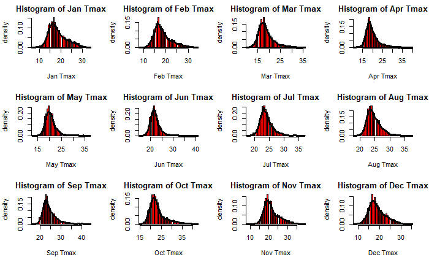

```r
par(mfrow=c(3,4))
for(i in 1:12){
  plotTx(Tmax,i,month)
}
```

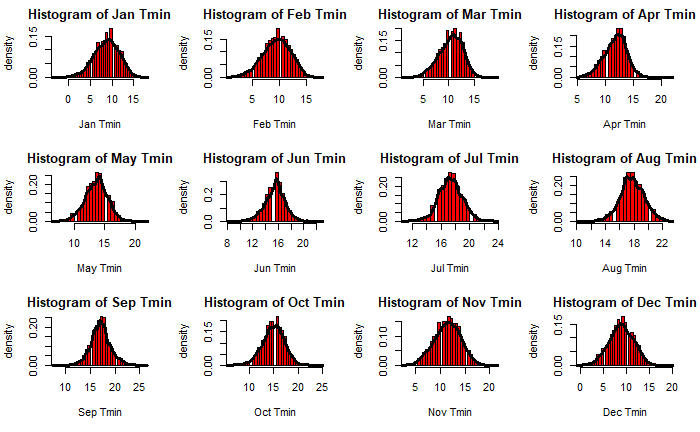

```r
for(i in 1:12){
  plotTn(Tmin,i,month)
}
```

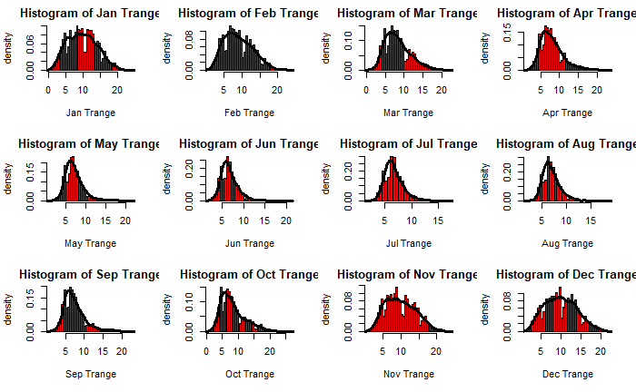

```r
for(i in 1:12){
  plotTrange(Trange,i,month)
}
```

define functions to plot seasonal histogram and kernel density curves

```r
seas=c("DJF","MAM","JJA","SON")
plotsesTx <- function(Tmax,i,seas){
  if(i==1){
    X=Tmax[which((Tmax[,2]==1)|(Tmax[,2]==2)|(Tmax[,2]==12)),5]
    hist(X,plot=TRUE,breaks=(max(X)-min(X))/0.5,col="red",main="Histogram of DJF Tmax",xlab="DJF Tmax",freq=FALSE,xlim=c(-0,45))
    dens <- density(X,adjust=1,kernel=c("gaussian"))
    lines(dens,lwd=3)
  }else{
    X=Tmax[which((Tmax[,2]==(12+(i-1)*3)%%12)|(Tmax[,2]==(12+(i-1)*3)%%12+1)|(Tmax[,2]==(((12+(i-1)*3)%%12)+2))),5]
    hist(X,plot=TRUE,breaks=(max(X)-min(X))/0.5,col="red",main=paste0("Histogram of ",seas[i]," Tmax"),xlab=paste0(seas[i]," Tmax"),freq=FALSE,xlim=c(0,45))
    dens <- density(X,adjust=1,kernel=c("gaussian"))
    lines(dens,lwd=3)
  }
}
plotsesTn <- function(Tmin,i,seas){
  if(i==1){
    X=Tmin[which((Tmin[,2]==1)|(Tmin[,2]==2)|(Tmin[,2]==12)),5]
    hist(X,plot=TRUE,breaks=(max(X)-min(X))/0.5,col="red",main="Histogram of DJF Tmin",xlab="DJF Tmin",freq=FALSE,xlim=c(-10,30))
    dens <- density(X,adjust=1,kernel=c("gaussian"))
    lines(dens,lwd=3)
  }else{
    X=Tmin[which((Tmin[,2]==(12+(i-1)*3)%%12)|(Tmin[,2]==(12+(i-1)*3)%%12+1)|(Tmin[,2]==((12+(i-1)*3)%%12)+2)),5]
    hist(X,plot=TRUE,breaks=(max(X)-min(X))/0.5,col="red",main=paste0("Histogram of ",seas[i]," Tmin"),xlab=paste0(seas[i]," Tmin"),freq=FALSE,xlim=c(-10,30))
    dens <- density(X,adjust=1,kernel=c("gaussian"))
    lines(dens,lwd=3)
  }
}
plotsesTrange <- function(Trange,i,seas){
  if(i==1){
    X=Trange[which((Trange[,2]==1)|(Trange[,2]==2)|(Trange[,2]==12)),5]
    hist(X,plot=TRUE,breaks=(max(X)-min(X))/0.5,col="red",main="Histogram of DJF Trange",xlab="DJF Trange",freq=FALSE,xlim=c(-10,30))
    dens <- density(X,adjust=1,kernel=c("gaussian"))
    lines(dens,lwd=3)
  }else{
    X=Trange[which((Trange[,2]==(12+(i-1)*3)%%12)|(Trange[,2]==(12+(i-1)*3)%%12+1)|(Trange[,2]==((12+(i-1)*3)%%12)+2)),5]
    hist(X,plot=TRUE,breaks=(max(X)-min(X))/0.5,col="red",main=paste0("Histogram of ",seas[i]," Trange"),xlab=paste0(seas[i]," Trange"),freq=FALSE,xlim=c(-10,30))
    dens <- density(X,adjust=1,kernel=c("gaussian"))
    lines(dens,lwd=3)
  }
}
```

plot seasonal histogram and kernel density curves

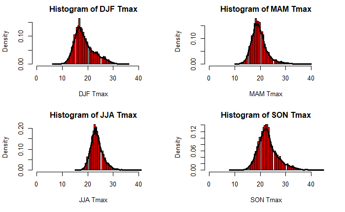

```r
par(mfrow=c(2,2))
for(i in 1:4){
  plotsesTx(Tmax,i,seas)
}
```

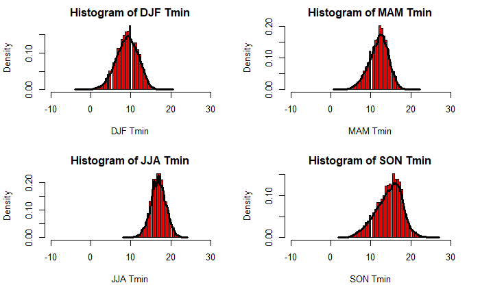

```r
for(i in 1:4){
  plotsesTn(Tmin,i,seas)
}
```

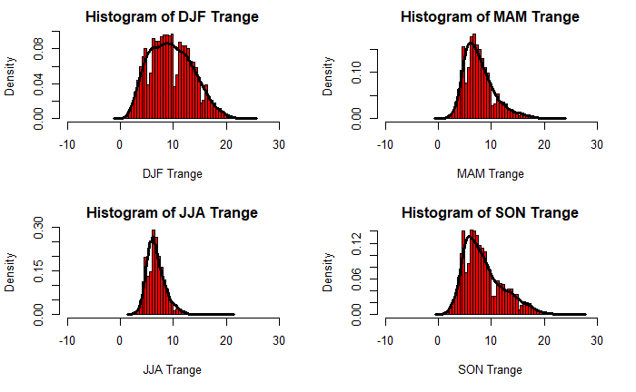

```r
for(i in 1:4){
  plotsesTrange(Trange,i,seas)
}
```

Bonus answer: the blank interval is not caused by the data error, but simply there is no data within those bins. For example, if I choose Tmax within (15,16), all available Tmax are 15.6, so I will get blank in (15,15.5] bin. If I choose a coarser bin, I will have fewer interval, if I choose thinner bin, I will get more blank intervals. Take (b) select Winter Tx as DJFTx, and calculate the statistics

```r
DJFTx <- Tmax[which((Tmax[,2]==1)|(Tmax[,2]==2)|(Tmax[,2]==12)),5]
meanDJFTx=sum(DJFTx)/length(DJFTx)
print(paste0("meanDJFTx=",meanDJFTx))
```

```
[1] "meanDJFTx=18.6640282367077"
```

```r
medianDJFTx=sort(DJFTx)[length(DJFTx)/2]
print(paste0("medianDJFTx=",medianDJFTx))
```

```
[1] "medianDJFTx=17.8"
```

```r
sdDJFTx=sqrt(1/(length(DJFTx)-1)*sum((DJFTx-meanDJFTx)^2))
print(paste0("sdDJFTx=",sdDJFTx))
```

```
[1] "sdDJFTx=3.93729647785861"
```

```r
masdDJFTx=1/length(DJFTx)*sum(abs(DJFTx-meanDJFTx))
print(paste0("masdDJFTx=",masdDJFTx))
```

```
[1] "masdDJFTx=3.12353053863384"
```

```r
quan1st=sort(DJFTx)[length(DJFTx)/4]
print(paste0("quan1st=",quan1st))
```

```
[1] "quan1st=16.1"
```

```r
quan3rd=sort(DJFTx)[length(DJFTx)*3/4]
print(paste0("quan3rd=",quan3rd))
```

```
[1] "quan3rd=21.1"
```

```r
skew=1/(length(DJFTx)-1)*sum((DJFTx-meanDJFTx)^3)/(sdDJFTx^3)
print(paste0("skewness=",skew))
```

```
[1] "skewness=0.764415222114507"
```

```r
###Using the direct kurtosis formula (ratio of the fourth moment and the second moment squared)
kurtosis=(sum((DJFTx-meanDJFTx)^4)/length(DJFTx))/((sum((DJFTx-meanDJFTx)^2))^2/(length(DJFTx))^2)
print(paste0("kurtosis=",kurtosis))
```

```
[1] "kurtosis=3.27273020623562"
```

print summary(DJFTx) to test

```r
summary(DJFTx)
```

```
   Min. 1st Qu.  Median    Mean 3rd Qu.    Max.
   7.80   16.10   17.80   18.66   21.10   34.40
```

```r
l=seq(0.5,-2,-0.5)
dl=array(0,dim=c(1,length(l))) ##"dlambda"
Ll=array(0,dim=c(1,length(l))) ##"L(lambda)"
for(i in 1:length(l)){
  if(l[i]==0){
    TranDJF=log(DJFTx)
    dl[i]=abs(mean(TranDJF)-median(TranDJF))/(sort(TranDJF)[length(TranDJF)*0.75]-sort(TranDJF)[length(TranDJF)*0.25])
    Ll[i]=(-length(TranDJF)/2)*log(sd(TranDJF)^2)+(l[i]-1)*sum(log(DJFTx))
  }else{
    TranDJF=(DJFTx^l[i]-1)/l[i]
    dl[i]=abs(mean(TranDJF)-median(TranDJF))/(sort(TranDJF)[length(TranDJF)*0.75]-sort(TranDJF)[length(TranDJF)*0.25])
    Ll[i]=(-length(TranDJF)/2)*log(sd(TranDJF)^2)+(l[i]-1)*sum(log(DJFTx))
  }
}
```

plot the change of dl and Ll as a function of l(lambda) to choose the best lambda

```r
index=seq(1,length(l),1)
plot(x=index,y=dl,type='b',lwd=3,col='black',xlab="lambda",ylab="d(lambda)")
par(new=T)
```

```r
plot(x=index,y=Ll,xlab=NA,ylab=NA,axes=F,type='b',col="red",lwd=3)
axis(side=4)
```

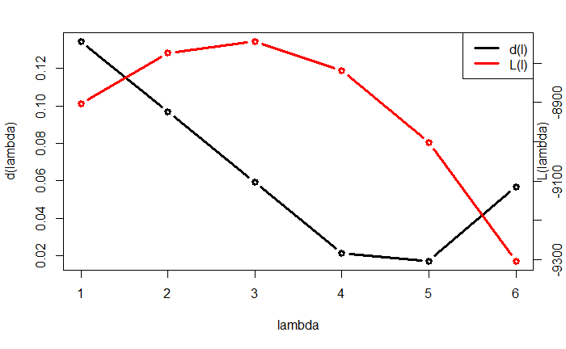

```r
mtext(side=4,'L(lambda)')
legend("topright",c("d(l)","L(l)"),lwd=c(3,3),col=c("black","red"))
```

If considering dl, I would choose l[5]=-1.5, if considering Ll, I would choose l[3]=-0.5. Plotting the two distributions as below to decide which to choose

```r
par(mfrow=c(1,2))
l=-0.5
TranDJF1=(DJFTx^l-1)/l
dl=abs(mean(TranDJF1)-median(TranDJF1))/(sort(TranDJF1)[length(TranDJF1)*0.75]-sort(TranDJF1)[length(TranDJF1)*0.25])
Ll=(-length(TranDJF1)/2)*log(sd(TranDJF1)^2)+(l-1)*sum(log(DJFTx))
hist(TranDJF1,plot=TRUE,col="red",breaks=20,main=paste0("Histogram of TranDJF when l=-0.5"),xlab="Winter Tmax",ylab="density",freq=FALSE)
dens <- density(TranDJF1,adjust=1,kernel=c("gaussian"))
lines(dens,lwd=3)
```

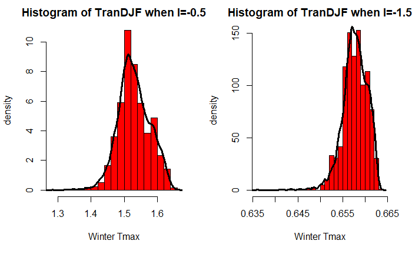

```r
l=-1.5
TranDJF2=(DJFTx^l-1)/l
dl=abs(mean(TranDJF2)-median(TranDJF2))/(sort(TranDJF2)[length(TranDJF2)*0.75]-sort(TranDJF2)[length(TranDJF2)*0.25])
Ll=(-length(TranDJF2)/2)*log(sd(TranDJF2)^2)+(l-1)*sum(log(DJFTx))
hist(TranDJF2,plot=TRUE,col="red",breaks=20,main=paste0("Histogram of TranDJF when l=-1.5"),xlab="Winter Tmax",ylab="density",freq=FALSE)
dens <- density(TranDJF2,adjust=1,kernel=c("gaussian"))
lines(dens,lwd=3)
```

```r
skew1=1/(length(TranDJF1)-1)*sum((TranDJF1-mean(TranDJF1))^3)/(sd(TranDJF1)^3)
print(paste0("skewness of TranDJF when l=-0.5: ",skew1))
```

```
[1] "skewness of TranDJF when l=-0.5: -0.0642221585981097"
```

```r
skew2=1/(length(TranDJF2)-1)*sum((TranDJF2-mean(TranDJF2))^3)/(sd(TranDJF2)^3)
print(paste0("skewness of TranDJF when l=-1.5: ",skew2))
```

```
[1] "skewness of TranDJF when l=-1.5: -0.805332667122404"
```

The skewness of TranDJF when l=-0.5 is much smaller, therefore, I would choose lambda=-0.5 as the lambda.

5. For the winter (DJF) Tx data,
1. Fit a gamma distribution using Thom’s approximation to the maximum likelihood estimates (see Wilks section 4.4.3). Answer: Using Thom’s approximation as below:

```r
D=log(mean(DJFTx))-1/length(DJFTx)*sum(log(DJFTx))
alpha=(1+sqrt(1+4*D/3))/(4*D)
print(paste0("alpha=",alpha))
```

```
[1] "alpha=23.7351447221839"
```

```r
beta=mean(DJFTx)/alpha
print(paste0("beta=",beta))
```

```
[1] "beta=0.786345668213412"
```

2. Fit a gamma distribution using the built-in functions of the software package of your choice. How similar/different are they? How did the software package calculate the parameters? Be careful of different parameterizations of the gamma.

```r
library(fitdistrplus)
fit.gamma <- fitdist(DJFTx, distr="gamma", method = "mle")
```

```
NaNs producedNaNs producedNaNs produced
```

```r
summary(fit.gamma)
```

```
Fitting of the distribution ' gamma ' by maximum likelihood
Parameters :
       estimate Std. Error
shape 23.731151 0.40843761
rate   1.271425 0.02211505
Loglikelihood:  -18295.29   AIC:  36594.59   BIC:  36608.19
Correlation matrix:
          shape      rate
shape 1.0000000 0.9894852
rate  0.9894852 1.0000000
```

Alpha=“shape” in fit.gamma, beta=1/rate in fit.gamma, so for built-in results, alpha=23.731151, beta=1/rate=0.7865191. They are very similar to the parameters fit using Thom’s approximation: alpha=23.735144, beta=0.786346 change in alpha=23.731151-23.735144=-0.003993 change in beta=0.7865191-0.786346=0.0001731 plot the two fitted curve to compare This software package calculate the parameters using Maximum likelihood method.

```r
index=as.numeric(seq(min(DJFTx),max(DJFTx),1))
fx=array(0,dim=c(1,length(index)))
fx=((index/beta)^(alpha-1))*exp(-index/beta)/(beta*gamma(alpha))
plot(x=index,y=fx,col="red",lwd=3,type='l')
lines(x=index,y=dgamma(index,fit.gamma$estimate["shape"],fit.gamma$estimate["rate"]),col="black",lty=2,lwd=3)
```

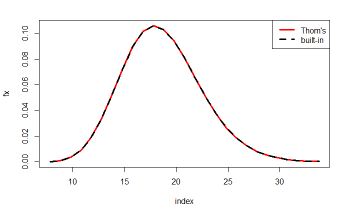

```r
legend("topright",c("Thom's","built-in"),lwd=3,lty=c(1,2),col=c("red","black"))
```

From here we can see that the Thom’s approximation result and the built-in fit results are almost identical.

(c)If the data X are in tenths of degrees of Celsius, then D=ln(10*mean(X))-1/n*sum(ln(10*X))=ln(10)+ln(mean(X))-1/n*sum(ln(10)+ln(X))=ln(10)+ln(mean(X))-1/n*nln(X)-1/n*sum(ln(X))=ln(mean(X))-1/n*sum(ln(X))=originalD Because alpha is only the function of D, D is unchanged, so alpha is unchanged. According to Thom’s approximation, beta=mean(X)/alpha, the mean(X) becomes 10 times mean(X) after reexpressing data in tenths of Celsius degree, so the beta becomes 10 times beta. So the alpha remains unchanged, beta becomes 10 times the original beta.

4. Construct a histogram of the temperature data, and superimpose the fitted gamma function.

```r
hist(DJFTx,plot=TRUE,col="yellow",breaks=20,main=paste0("Histogram of winter Tx"),xlab="Winter Tmax",ylab="density",freq=FALSE)
lines(x=index,y=fx,lwd=3,col='red')
```

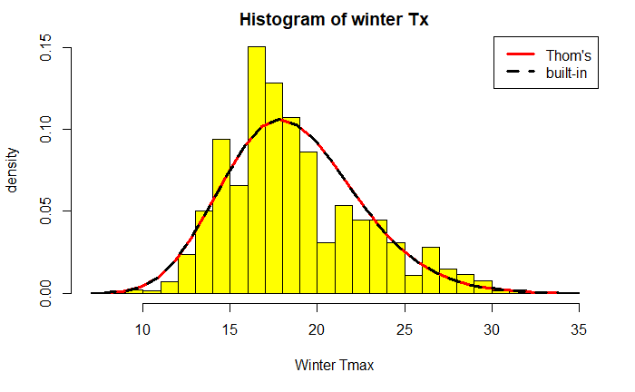

```r
lines(x=index,y=dgamma(index,fit.gamma$estimate["shape"],fit.gamma$estimate["rate"]),col="black",lty=2,lwd=3)
legend("topright",c("Thom's","built-in"),lwd=3,lty=c(1,2),col=c("red","black"))
```

5. Comment on the goodness of fit of fit of the distribution, including creating a quantile-quantile plot (see section 4.5 in Wilks)

```r
n=length(DJFTx)
probabilities=(seq(1,n,1)-1/3)/(n+1/3)
gamma.quantiles=qgamma(probabilities,shape=23.7351447,scale=0.7863457)
plot(sort(DJFTx),sort(gamma.quantiles),xlab='Sample quantiles',ylab='Theoretical quantiles',pch=1,col="red")
abline(0,1)
```

```r
gamma.quantiles=qgamma(probabilities,shape=23.731151,scale=0.7865191)
par(new=T)
plot(sort(DJFTx),sort(gamma.quantiles),pch=2,col="blue",cex=0.5,xlab=NA,ylab=NA)
```

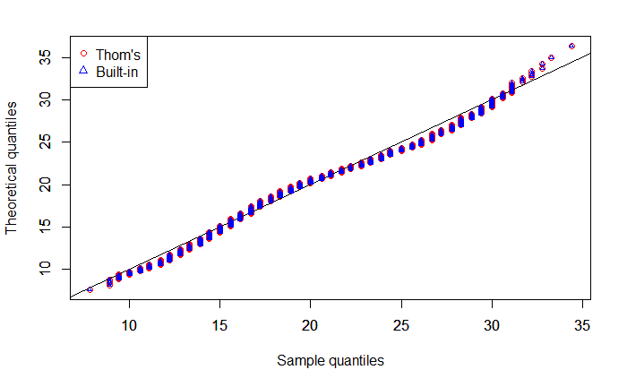

```r
legend("topleft",c("Thom's","Built-in"),col=c("red","blue"),pch=c(1,2))
```

6. On August 13, 2013, the maximum temperature recorded in Los Angeles was 33.3 Celsius degree. Use the entire Los Angeles T x data set to provide context for such a warm temperature.
1. Find the fraction of JJA days that were at least this warm.

```r
JJATx <- Tmax[which((Tmax[,2]==6)|(Tmax[,2]==7)|(Tmax[,2]==8)),5]
fraction=length(which(JJATx>=33.3))/length(JJATx)
print(fraction)
```

```
[1] 0.00570676
```

2. Fit a normal distribution to JJA Tx . Convert the 33.3 Celsius degree value into a standard anomaly. Use the table in the back of Wilks to find the probability of observing a day at least this hot, based on the normal fit. Interpret the result, describing and discussing the appropriateness of any assumptions that you have made (form of the distribution, independence, stationarity).

```r
library(fitdistrplus)
fit.norm <- fitdist(JJATx, distr="norm", method = "mle")
```

```
NaNs producedNaNs produced
```

```r
summary(fit.norm)
```

```
Fitting of the distribution ' norm ' by maximum likelihood
Parameters :
      estimate Std. Error
mean 23.632807 0.03098086
sd    2.561126 0.02190676
Loglikelihood:  -16124.04   AIC:  32252.08   BIC:  32265.74
Correlation matrix:
             mean           sd
mean 1.000000e+00 1.543164e-10
sd   1.543164e-10 1.000000e+00
```

```r
(33.3-(fit.norm$estimate["mean"]))/(fit.norm$estimate["sd"])
```

```
    mean
3.774587
```

So the standard anomaly is 3.774587 sigma. According to the table in the back of Wilks, the probability of observing a day at least this hot is : 0.00008 0.00008<<0.00570676, the probability is too small, indicating the right tail of the JJATx is too thin in the normal fit. Plot the histogram and overlay the fitted curve to see:

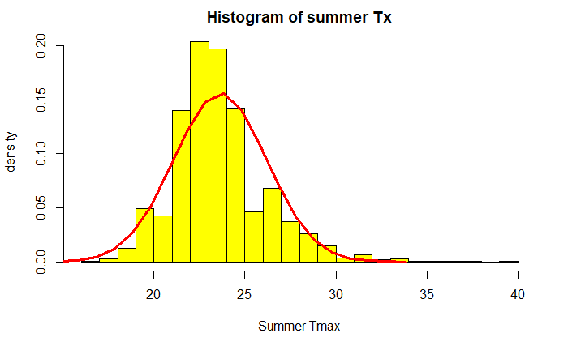

```r
index=as.numeric(seq(min(DJFTx),max(DJFTx),1))
fx1=array(0,dim=c(1,length(index)))
fx1=dnorm(index,mean=fit.norm$estimate["mean"],sd=fit.norm$estimate["sd"])
hist(JJATx,plot=TRUE,col="yellow",breaks=20,main=paste0("Histogram of summer Tx"),xlab="Summer Tmax",ylab="density",freq=FALSE)
lines(x=index,y=fx1,lwd=3,col='red')
```

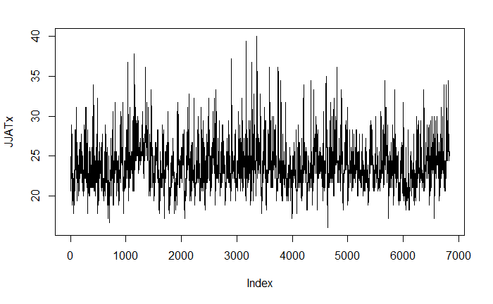

```r
plot(JJATx,type='l')
```

There’s no significant trend seen using eyeball, and the pattern of varying remains similar across time, so the stationarity assumption seems to be correct. Check the independence

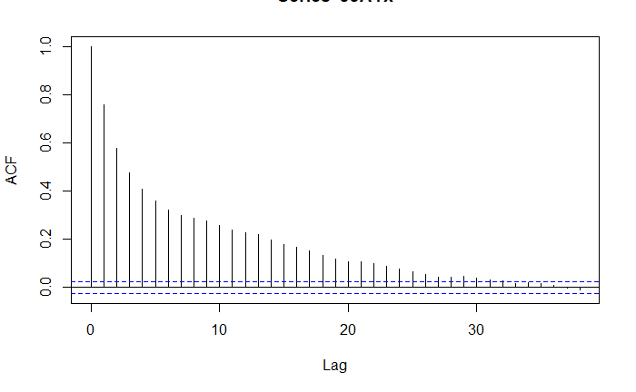

```r
a<-acf(JJATx, plot=T)
```

Directly plotting the autocorrelation shows there are autocorrelation for neighbouring data, so the assumption of independence might not be correct enough. (c) Read the Wilks section about the generalized extreme value distribution. (d) Find the maximum value of Tx for each year in the data set. Plot as a histogram and demarcate the value from August 13, 2013 in some way. Find the fraction of years that feature a maximum Tx hotter than 33.3 Celsius degree. Interpret this result, and in particular discuss how this approach avoids the issue of very warm days tending to be tightly clustered in time that may mar the interpretation in (a) and (b).

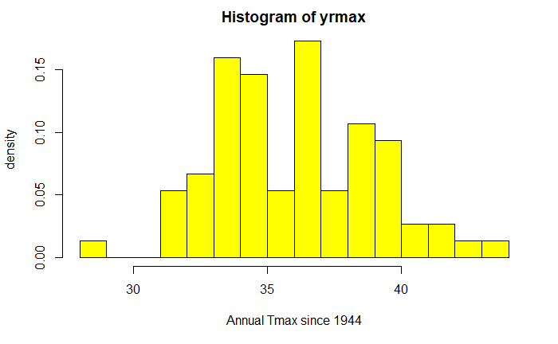

```r
nyr=max(Tmax[,1])-min(Tmax[,1])+1
yrmax=rep(0,nyr)
for (i in 1:nyr){
  yrmax[i]=max(Tmax[which(Tmax[,1]==min(Tmax[,1])+(i-1)),5])
}
hist(yrmax,plot=TRUE,col="yellow",breaks=20,xlab="Annual Tmax since 1944",ylab="density",freq=FALSE)
```

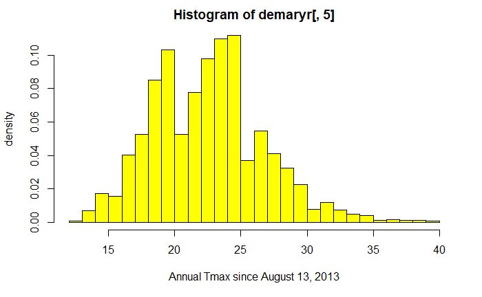

```r
demaryr=Tmax[which(Tmax[,1]*10000+Tmax[,2]*100+Tmax[,3]>=20130813),]
hist(demaryr[,5],plot=TRUE,col="yellow",breaks=20,xlab="Annual Tmax since August 13, 2013",ylab="density",freq=FALSE)
```

```r
fractYTx=length(which(yrmax>33.3))/nyr
fractYTx
```

```
[1] 0.7466667
```

```r
print(paste0("the fraction of years that feature a maximum Tx hotter than 33.3 Celsius degree: ",fractYTx))
```

```
[1] "the fraction of years that feature a maximum Tx hotter than 33.3 Celsius degree: 0.746666666666667"
```

7. For the June temperature data in Table A.3,
1. Use a two-sample t test to investigate whether the average June temperatures in El Nino and non-El Nino years are significantly different. #Assume that the variances are unequal and that the Gaussian distribution is an adequate approximation to the distribution of the test statistic.

```r
Allyr=read.table("Table A.3.txt",header = TRUE)
ENyr=Allyr[c(1,3,7,15,19),]
NonENyr=Allyr[c(2,4:6,8:14,16:18,20),]
meanEN=mean(ENyr[,2])
meanNonEN=mean(NonENyr[,2])
varEN=var(ENyr[,2])   ##sample variance
varNonEN=var(NonENyr[,2]) ##sample variance
n1=length(ENyr[,2])
n2=length(NonENyr[,2])
Z=(meanEN-meanNonEN)/(sqrt(varEN/n1+varNonEN/n2))
p=pnorm(Z,sd=1,mean=0)
print(paste0("p(z<Z)=",p,">0.975"))
```

```
[1] "p(z<Z)=0.999999498465779>0.975"
```

Because the pnorm of Z is larger than 0.975, so under an alpha=0.05 assumption, the null hypothesis can be rejected. The average June temperaatures in El Nino and non-El Nino years are significantly different. b. Construct a 95% confidence interval for the difference in average June temperature between El Nino and non-El Nino years.

```r
lowerlevel=qnorm(0.025)
upperlevel=qnorm(1-0.025)
Zlower=lowerlevel*sqrt(varEN/n1+varNonEN/n2)
Zupper=upperlevel*sqrt(varEN/n1+varNonEN/n2)
print(paste0("95% confidence interval for meanEN-meanNonEN: (",Zlower,",",Zupper,")"))
```

[output not shown]